# Как же измененяется уровень самоубийств в РФ?

Stanislav

## Введение

С конца 2018 г. многие отмечают рост депрессивных и суицидальных настроений в обществе, что отражается в массовой культуре (мемчики), так и в повседневном общении с коллегами и друзьями. И тогда меня посетила мысль узнать, кто же чаще всего убивается в России, и, действительно ли, в последние годы стало больше самоубийств? Что и является целью этого мини-исследования.

## Описание данных

Данные взяты из открытого источника: https://www.kaggle.com[^1]. В них отображено количество самоубийств в различных странах с 1985 по 2016 гг., также наблюдения разделены по возрастным группам и полу. Так же данные содержат такие переменные как: “ВВП”, “Название поколения”, “Популяция” и “Индекс человеческого развития”. Для исследования я отобрал наблюдения, касающиеся РФ, и сделал небольшую сводную таблицу, где указаны: среднее, максимальное и минимальное количество самоубийств в различных возрастных категориях среди мужчин и женщин,а также годы, когда наблюдалось максимальное и минимальное количество самоубийств.

Таблица 1. Число самоубийств на 100 тыс. человек по группам

| sex | age | m.suicides.no | max.suicides.no | min.suicides.no | year.with.max.suicides | year.with.min.suicides |
| --- | --- | --- | --- | --- | --- | --- |
| женщины | 15-24 years | 7.8 | 9.9 | 4.9 | 1999 | 2015 |
| женщины | 25-34 years | 9.1 | 11.4 | 6.0 | 1995 | 2015 |
| женщины | 35-54 years | 11.2 | 16.4 | 6.1 | 1995 | 2014 |
| женщины | 55-74 years | 14.2 | 20.7 | 5.8 | 1993 | 2015 |
| женщины | 75+ years | 26.4 | 35.4 | 13.7 | 1989 | 2015 |
| мужчины | 15-24 years | 42.8 | 60.1 | 24.1 | 2001 | 2015 |
| мужчины | 25-34 years | 69.3 | 94.2 | 40.2 | 1994 | 2015 |
| мужчины | 35-54 years | 76.9 | 117.3 | 40.3 | 1994 | 2015 |
| мужчины | 55-74 years | 71.8 | 103.9 | 35.4 | 1994 | 2015 |
| мужчины | 75+ years | 85.7 | 110.2 | 58.2 | 1994 | 2015 |

## Анализ и графики

Как видно из таблицы 1 наблюдается существенная разница между количеством самоубийств между мужчинами и женщинами во всех возрастных группах. Также заметно, что минимальное количество самоубийств приходится на последние годы во всех группах. Для наглядности, а также, чтобы проследить динамику развития “убивания себя” построим график и сразу разделим мужчин и женщин:

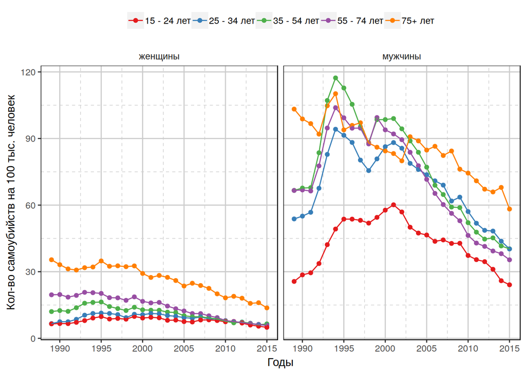

Очевидно, что мужчины являются абсолютными лидерами по части самоубиств во всех возрастных категориях по сравнению с женщинами. Хотя в обоих случаях заметно уменьшение роста самоубийств, начиная с ранних 2000-х. Как видно из таблиц и графиков, моя теория об увеличении роста самоубийств была неверна. Тогда хотя бы проверим, является ли это уменьшение статистически значимым. Для этого используем t-критерий Стьюдента.

Таблица 2. p-value одностроннего t-test’a

| age | sex | p-value | Нижняя границ |
| --- | --- | --- | --- |
| 15-24 years | женщины | 0.0e+00 | 8.5 |
| 15-24 years | мужчины | 0.0e+00 | 48.7 |
| 25-34 years | женщины | 0.0e+00 | 10.0 |
| 25-34 years | мужчины | 0.0e+00 | 77.7 |
| 35-54 years | женщины | 0.0e+00 | 12.9 |
| 35-54 years | мужчины | 1.0e-15 | 89.4 |
| 55-74 years | женщины | 7.2e-14 | 16.9 |
| 55-74 years | мужчины | 1.0e-15 | 83.6 |
| 75+ years | женщины | 0.0e+00 | 29.9 |
| 75+ years | мужчины | 0.0e+00 | 92.5 |

Как видно из теста, изменения внутри всех групп оказались значимы. Так же в датасете присутствуют значения ВВП на душу населения. Изобразим временную изменчивость ВВП и совместим с “мужскими самоубийствами”

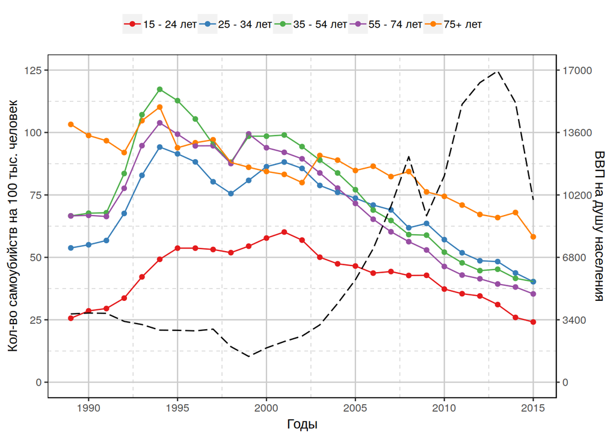

Если пристально присмотреться к этому графику, то можно увидеть отрицательную корреляцию с лагом примерно три года (т.е. сначала понижается ППС, а потом следует повышением уровня самоубийств среди мужчин). Оценим коэффициент корреляции в каждой возрастной группе среди мужского населения РФ

Таблица 3. Коэффициенты корреции между ППС и разными возрастными группами мужского населения

[output not shown]

[^1]: [Ссылка на скачивание данных](https://www.kaggle.com/russellyates88/suicide-rates-overview-1985-to-2016)